# POLI 110

November 6, 2025

## Testing Causal Claims

### **1. Correlation: Recap**

- definition
- attributes
- problems

### **2. Problems with Correlation**

- Random correlation
- Bias in correlation (**confounding**)
- Today is a very good day to ask questions

## Recap

## Solving FPCI

We “solve” the FPCI by comparing **factual** outcomes in **different cases** that have **different exposures** to the “cause”

- \(\mathrm{Case \ A}\) is exposed to a “cause”
- \(\mathrm{Case \ B}\) is **not** exposed to a “cause”

This is **correlation**: the degree of association/relationship between the **observed** values of \(X\) (the independent variable) and \(Y\) (the dependent variable)

- To *infer* causality, we assume that \(\mathrm{Case \ B}\) is the same as the counterfactual \(\color{red}{\mathrm{Case \ A}}\)

## **Correlation**

Correlations have

- **direction**:
  - positive: implies that as \(X\) increases, \(Y\) increases
  - negative: \(X\) increases, \(Y\) decreases
- **strength** (has nothing to do **size of effect**):
  - **strong**: \(X\) and \(Y\) almost **always** move together (near \(1,-1\))
  - **weak**: \(X\) and \(Y\) do not move together very much (near \(0\))
- **magnitude**:
  - this is the how much \(Y\) changes with \(X\).
  - The larger the effect of \(X\) on \(Y\), the steeper the slope

[figure not shown]

## Correlation

### **Two types of problems**

- **random association**: correlations between \(X\) and \(Y\) occur **by chance** and do not reflect \(X\) causing \(Y\).
- **bias** (spurious correlation, **confounding**): \(X\) and \(Y\) are correlated but the correlation does not result from a **causal relationship** between those variables

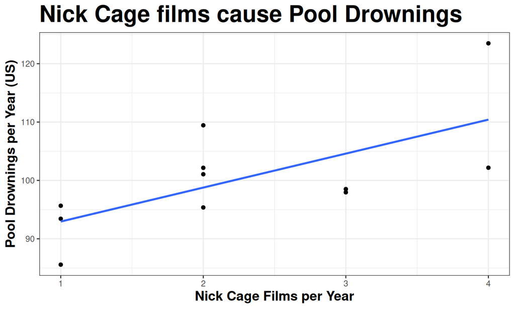

## Random assocation

What is the **problem**?

If correlation can occur by chance:

- we can observe a positive correlation between \(X\) and \(Y\) and conclude that \(X\) causes \(Y\), even if \(X\) has no effect on \(Y\)
- failure of weak severity

## Random assocation

What is the **solution**?

1. Obtain **probability** of observing *this* correlation by chance:
   - **strength** of correlation
   - **size** of the sample (\(N\))
   - assume we know the **random process** generating our observations
2. \(p\)-values: probability of *this* correlation by chance
   - Given same \(N\), stronger correlation has lower \(p\)
   - Given same strength, correlation with more \(N\) has lower \(p\)
   - probability we incorrectly infer a *real* relationship (due to chance), if used correctly

### \(p\) hacking:

What is the problem with looking at many correlations and reporting only those that are “significant”? (\(p < 0.05\))

- We [play a game](https://rolladie.net/roll-a-d20-die#!numbers=1&high=20&length=1&sets=&addfilters=&last_roll_only=true&totals_only=false) where you win if you roll “20” on a 20-sided die (probability is 1 in 20 (\(0.05\))
- What is the probability you win if you roll once?
- What is the probability you win if you roll twenty times?
- 64%! Looking at lots of correlations, you are likely to find at some “unlikely” correlations

| Statistical Significance | \(p\)-value | By Chance? | Why? | “Real”? |
| --- | --- | --- | --- | --- |
| Low | High \((p > 0.05)\) | Likely | small \(N\) weak correlation | Probably **not** |
| High | Low \((p < 0.05)\) | Unlikely | large \(N\) strong correlation | Probably |

**Practice**

[figure not shown]

## Example

[video not shown]

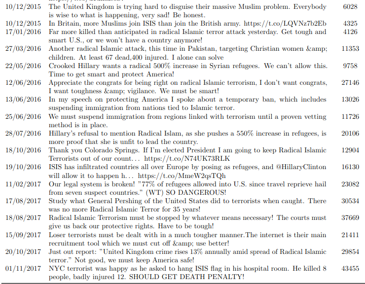

## Trump’s Twitter and Hate Crimes

[Mueller and Schwarz (2023)](https://www.aeaweb.org/articles?id=10.1257/app.20210211) investigate:

During the period from 2015 to the end of 2017, Trump posted more than 300 messages that can be classified as “Anti-Muslim”.

Did Trump’s tweeting of anti-Muslim messages on social media **increase** anti-Muslim hate crimes?

## Trump’s Twitter and Hate Crimes

We can’t observe the US in the absence of Trump tweeting against Muslims, so authors use correlation…

### Trump’s Twitter and Hate Crimes

\(X\) (Independent Variable): Trump’s Twitter gained attention after he announced run for President (2015-2017)

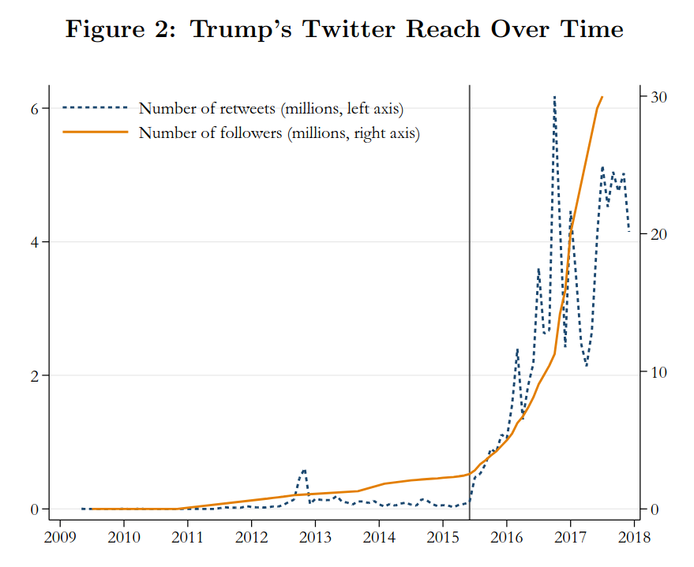

### Trump’s Twitter and Hate Crimes

\(Y\) (Dependent variable): When Trump gained prominence, anti-Muslim hate crimes increased

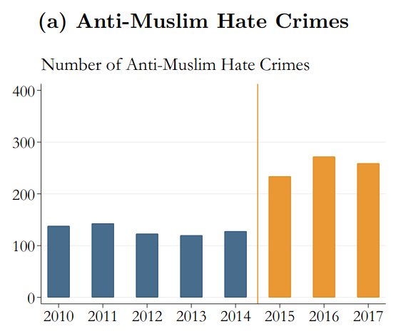

## Trump’s Twitter and Hate Crimes

As Trump’s Tweeting against Muslims reached more people (change in observed \(X\)), anti-Muslim hate crimes increased (change in \(Y\))

In groups, discuss:

Is this correlation be convincing that Trump’s tweets **caused** anti-Muslim hate crimes?

Why or why not?

In this case, correlation “solves” FPCI by plugging in these factual potential outcomes

| Case | Tweets | No Tweets |
| --- | --- | --- |
| USA 2015-17 | \(\mathrm{Hate \ Crime_{USA \ 2015-17}(Trump \ Tweets)}\) | \(\color{red}{\mathrm{Hate \ Crime_{USA \ 2015-17}(No \ Tweets)}}\) |
|  | \(\Downarrow\) | \(\Uparrow{}\) |
| USA 2010-14 | \(\color{red}{\mathrm{Hate \ Crime_{USA \ 2010-14}(Trump \ Tweets)}}\) | \(\mathrm{Hate \ Crime_{USA \ 2010-14}(No \ Tweets)}\) |

## Example:

[figure not shown]

**Why** doesn’t correlation imply causation?

## Confounding

**confounding** is when there is a **systematic** observed correlation between \(X\) and \(Y\) that does **NOT reflect** the causal effect of \(X\) on \(Y\).

- This is **not** a chance correlation: if we looked at more data, relationship would persist
- Two ways to explain why this happens (different explanations, but two sides of the same coin)

## Confounding

Mueller and Schwarz look at the correlation of Trump’s Twitter activity and Hate Crimes over time:

When Trump tweeted more (and had more followers) (2015-2017), hate crimes were higher than when Trump tweeted less (and had fewer followers) (2010-2014).

- What do we have to **assume** in order for this correlation to imply causation? (HINT: Think about the potential outcomes we just looked at)

## Confounding

In order for Mueller and Schwarz’s correlation to imply causation, need to assume that:

\(\color{red}{\mathrm{AntiMuslim \ Hate \ Crime_{USA \ 2015-17}(No \ Trump \ Tweets)}}\) \(=\) \(\mathrm{AntiMuslim \ Hate \ Crime_{USA \ 2010-14}(No \ Trump \ Tweets)}\)

If assumption is wrong…

and Anti-Muslim hate crimes in 2015-2017 would have been different from 2010-2014 even **without Trump’s Tweets**…

…this comparison leads to confounding.

### Confounding

In correlation, Mueller and Schwarz assume that US (2015-17) without Trump tweets (counterfactual) is the same as US (2010-14) without Trump tweets (factual)

| Case | Tweets | No Tweets |
| --- | --- | --- |
| USA 2015-17 | \(\mathrm{Hate \ Crime_{USA \ 2015-17}(Trump \ Tweets)}\) | \(\color{red}{\mathrm{Hate \ Crime_{USA \ 2015-17}(No \ Tweets)}}\) |
|  | \(\Downarrow{=}\) | \(\Uparrow{=}\) |
| USA 2010-14 | \(\color{red}{\mathrm{Hate \ Crime_{USA \ 2010-14}(Trump \ Tweets)}}\) | \(\mathrm{Hate \ Crime_{USA \ 2010-14}(No \ Tweets)}\) |

### Confounding

If this substitution is **wrong**: USA in 2010-14 vs USA 2015-17 have **different** potential outcomes of hate crime, correlation is **biased**.

| Case | Tweets | No Tweets |
| --- | --- | --- |
| USA 2015-17 | \(\mathrm{Hate \ Crime_{USA \ 2015-17}(Trump \ Tweets)}\) | \(\color{red}{\mathrm{Hate \ Crime_{USA \ 2015-17}(No \ Tweets)}}\) |
|  | \(\Downarrow{\neq}\) | \(\Uparrow{\neq}\) |
| USA 2010-14 | \(\color{red}{\mathrm{Hate \ Crime_{USA \ 2010-14}(Trump \ Tweets)}}\) | \(\mathrm{Hate \ Crime_{USA \ 2010-14}(No \ Tweets)}\) |

Maybe \(\mathrm{Hate \ Crime_{USA \ 2015-17}(Trump \ Tweets)} = \\ \color{red}{\mathrm{Hate \ Crime_{USA \ 2015-17}(No \ Tweets)}}\): hate crimes would have gone up ANYWAY

## Confounding

**Why does confounding happen?**

### **Explanation 1**:

Confounding happens when cases that experience **different levels of \(X\)** have **systematically different** (factual and counterfactual) potential outcomes of \(Y\).

Cases with different levels of cause \(X\)

- **systematically different** in their factual/counter-factual values of \(Y\).

Does social media use cause increased polarization?

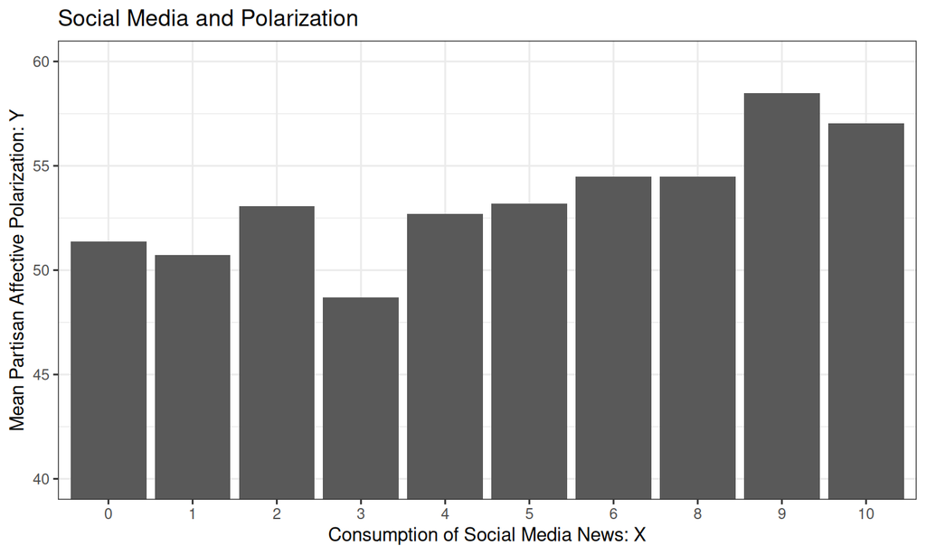

Individual data on social media use and affective polarization from ANES 2024

## Confounding

**Why does confounding happen?**

### **Explanation 1**:

Confounding happens when cases that experience **different levels of \(X\)** have **systematically different** (factual and counterfactual) potential outcomes of \(Y\).

What does that look like in the context of social media consumption and polarization?

::BOARD::

## Confounding

**Why does confounding happen?**

### **Explanation 1**:

Confounding happens when cases that experience **different levels of \(X\)** have **systematically different** (factual and counterfactual) potential outcomes of \(Y\).

Cases that actually receive cause \(X\)…

1. have a **different baseline** outcome (different \(Y\) absent \(X\)): **selection bias**
2. **respond differently** to cause \(X\): **heterogeneity bias**

… than cases **not** actually receiving \(X\)

## Confounding

### **Explanation 2**:

Confounding occurs when there are **other differences** between cases (call them variables, e.g. \(W\), etc.) that **causally affect \(X\) *and* \(Y\)**.

The easiest way to understand this is **visually**.

## Causal Graphs

Causal graphs represent a model of the **true causal relationships** between variables.

the **nodes** or **dots** correspond to **variables**

- can be labeled with generic names for independent/dependent variables (\(X\), \(Y\)) or meaningful names (e.g. “Trump Tweets”, “Hate Crimes”)

the **arrows** convey the **direction** of the flow of **causality**

- \(X \rightarrow Y\) means that \(X\) causes changes in \(Y\)
- \(X \leftarrow W\) means that \(W\) causes changes in \(X\)

Arrows alone do not indicate whether \(X\), e.g., increases or decreases \(Y\).

## Causal Graphs

### **For example**

Did Trump anti-Muslim tweets cause hate crimes?

- Islamist terrorist attacks \(\xrightarrow{}\) Trump anti-Muslim tweets
- Islamist terrorist attacks \(\xrightarrow{}\) News Coverage
- News coverage \(\xrightarrow{}\) anti-Muslim attitudes \(\xrightarrow{}\) Hate crimes

Did Trump anti-Muslim tweets cause hate crimes?

Maybe…

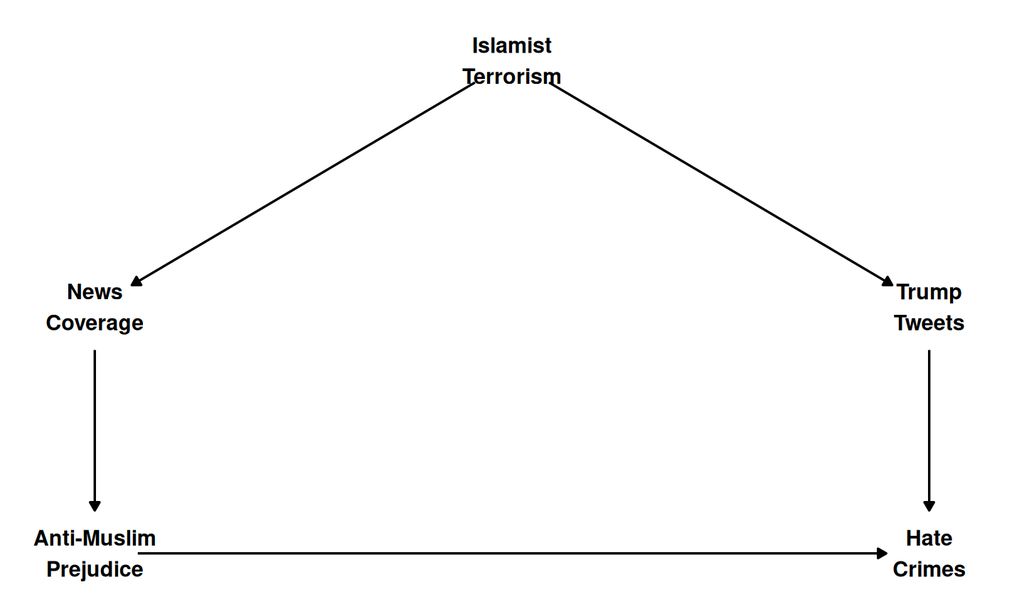

## Causal Graphs

In a causal graph, there is **confounding** of correlation of \(X\) and \(Y\) if…

1. any variable \(W\) has a causal path (of any length) toward \(X\) and \(Y\)
2. (equivalently) there is **backdoor** path or **non-causal** path from \(X\) to \(Y\)
   - a chain of **two** or more arrows that follows arrows **backwards** from of \(X\), changes direction **once** and follows arrows **toward** \(Y\): \(X \leftarrow W \leftarrow Z \rightarrow Y\)

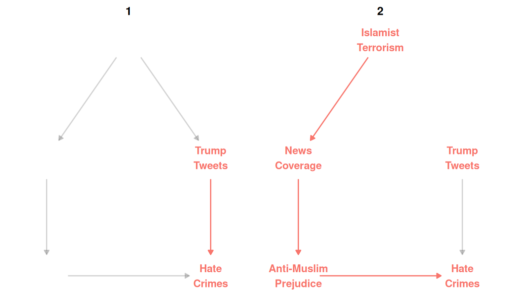

Does social media use cause increased polarization?

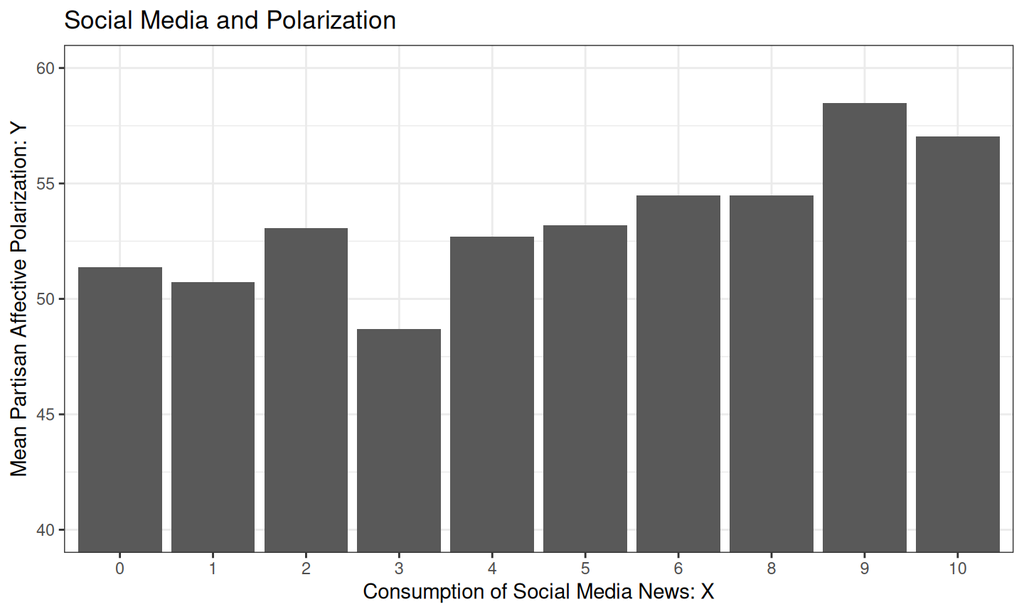

In groups: what other variables might affect social media use? polarization?

## Causal Graphs: Confounding

We don’t know the **True** causal graph (if we did, we wouldn’t need work so hard to evaluate causal claims)

Instead, these causal graphs help us think through **possible scenarios** that might produce **bias**/**confounding** of the correlation between \(X\) and \(Y\).

## Confounding

These examples illustrate the possibility that if causal graphs include variables **in addition** to the independent and dependent variables, there is a risk of confounding or bias.

Do **all** additional variables produce **confounding**?

**No…** We will discuss three different patterns of variables: some of which produce confounding, some which do not.

## Conclusion

The most serious threat to empirical evidence of causality is **confounding**:

- We can’t observe causal effects of \(X\) for individual cases (FPCI)
- Using correlation may lead us astray if other factors affect \(X\) and \(Y\)
- (theories about) Confounding can be diagnosed visually